solutions

# Getting Started with caladaptR

# Overview

This Notebook will demonstrate how you can use caladaptR to:

- create a Cal-Adapt API request object for a point location
- fetch data from Cal-Adapt
- plot the data as a time series

# Setup

The first thing we do is to load caladaptR and the other package we’re going to need. (If you haven’t installed these yet, see this [setup script](https://github.com/ucanr-igis/caladaptr-res/blob/main/docs/workshops/ca_intro_oct21/scripts/caladaptr_setup.R)).

```r
library(caladaptr)
library(units)
library(ggplot2)
library(dplyr)
library(sf)
library(tidyr)
```

We use the `conflicted` package to tell R which package we want it to use for some common function names:

```r
library(conflicted)
conflict_prefer("filter", "dplyr", quiet = TRUE)
conflict_prefer("count", "dplyr", quiet = TRUE)
conflict_prefer("select", "dplyr", quiet = TRUE)
```

# Part I. Get temperature data for a point location

In Part I, you generate a time series plot of projected maximum annual temperature like the one below for a point location using the four recommended GCMs for California and emissions scenario RCP 4.5.

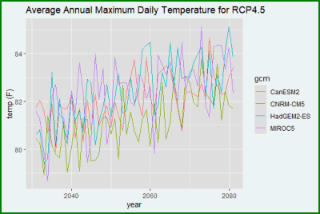

## 1. Create the API Request

The first step in getting climate variables back is to create a Cal-Adapt API request object. This involves stringing together a series of functions that specify the pieces of the request.

The following will create an API request for projected temperature data from Scripps:

```r
pt1_cap <- ca_loc_pt(coords = c(-119.168765, 35.487802)) %>%
  ca_gcm(gcms[1:4]) %>%
  ca_scenario(c("rcp45", "rcp85")) %>%
  ca_period("year") %>%
  ca_years(start = 2030, end = 2080) %>%
  ca_cvar(c("tasmin", "tasmax"))
```

**Pro Tip:**

- the order of the constructor functions doesn’t matter
- when entering coordinates, they must be i) in decimal degrees, and ii) formatted as *longitude, latitude* (in that order!)
- this example creates an API request for modeled climate data; for other datasets you might use different constructor functions
- you don’t have to memorize a bunch of keywords. `caladaptr` has several built-in constants that contain the values you can pass to API construction functions, including `gcms`, `scenarios`, `cvars`, and `periods`.

### Challenge 1

Enter the following constants to see what they contain `gcms`, `scenarios`, `cvars`, and `periods` [[Answer](https://bit.ly/3kRUP5Y)].

```r
gcms
```

```
 [1] "HadGEM2-ES" "CNRM-CM5"   "CanESM2"    "MIROC5"     "ACCESS1-0"  "CCSM4"      "CESM1-BGC"
 [8] "CMCC-CMS"   "GFDL-CM3"   "HadGEM2-CC" "ens32avg"   "ens32max"   "ens32min"
```

```r
scenarios
```

```
[1] "rcp45"      "rcp85"      "historical"
```

```r
cvars
```

```
 [1] "tasmax"     "tasmin"     "pr"         "swe"        "baseflow"   "et"         "rainfall"
 [8] "runoff"     "snowfall"   "soilMoist1" "Tair"
```

```r
periods
```

```
[1] "day"    "month"  "year"   "30yavg"
```

**Pro Tip:**

- not every combination of GCM, scenario, climate variable, and period has a data set
- these constants are useful for constructing API requests for modeled climate data; they may not be needed for other datasets

## 2. Examine an API Request

To see what’s in an API request object, type its name at the console:

```r
pt1_cap
```

```
Cal-Adapt API Request
Location(s):
  x: -119.169
  y: 35.488
Variable(s): tasmin, tasmax
Temporal aggregration period(s): year
GCM(s): HadGEM2-ES, CNRM-CM5, CanESM2, MIROC5
Scenario(s): rcp45, rcp85
Dates: 2030-01-01 to 2080-12-31
```

**Pro Tip:**

- you can customize the colors with `ca_settings()`. Let `console_colors` = `"dark"` or `light` depending on your RStudio color background.

```r
ca_settings(console_colors = "dark")
```

```
Console colors updated:
  Accent 1
  Accent 2
  Accent 3
  Accent 4
  Message
  Success
```

```r
pt1_cap
```

```
Cal-Adapt API Request
Location(s):
  x: -119.169
  y: 35.488
Variable(s): tasmin, tasmax
Temporal aggregration period(s): year
GCM(s): HadGEM2-ES, CNRM-CM5, CanESM2, MIROC5
Scenario(s): rcp45, rcp85
Dates: 2030-01-01 to 2080-12-31
```

You can double-check if your API request is complete by passing it to `ca_preflight()`:

```r
pt1_cap %>% ca_preflight()
```

```
General issues
 - none found
Issues for querying values
 - none found
Issues for downloading rasters
 - none found
```

To verify the location in an API request, you can plot it:

```r
plot(pt1_cap)
```

[interactive chart not shown]

**Pro Tip:**

- To view the LOCA grid cells, add `locagrid = TRUE` to the plot command.

```r
plot(pt1_cap, locagrid = TRUE)
```

[interactive chart not shown]

#### Your Turn:

Where is this point located? [[Answer](https://bit.ly/3uqUx96)].

Answer: in Shafter (outside Bakersfield), Kern County, CA

## 3. Fetch Data

Now it’s time to fetch data by feeding our API request into `ca_getvals_tbl()`. The object returned will be a tibble (data frame):

```r
pt1_tbl <- pt1_cap %>% ca_getvals_tbl(quiet = TRUE)

head(pt1_tbl)
```

| id | cvar | period | gcm | scenario | spag | dt | val |
| --- | --- | --- | --- | --- | --- | --- | --- |
| 1 | tasmin | year | HadGEM2-ES | rcp45 | none | 2030-12-31 | 285.8421 [K] |
| 1 | tasmin | year | HadGEM2-ES | rcp45 | none | 2031-12-31 | 285.6879 [K] |
| 1 | tasmin | year | HadGEM2-ES | rcp45 | none | 2032-12-31 | 285.7592 [K] |
| 1 | tasmin | year | HadGEM2-ES | rcp45 | none | 2033-12-31 | 285.1163 [K] |
| 1 | tasmin | year | HadGEM2-ES | rcp45 | none | 2034-12-31 | 285.9141 [K] |
| 1 | tasmin | year | HadGEM2-ES | rcp45 | none | 2035-12-31 | 285.3445 [K] |

## 4. Wrangle the Results for Plotting

To produce the desired time series plot, we need to i) pull out just values for RCP 4.5, and ii) convert degrees to °F. For the unit conversion, we can use the handy `set_units` function from the `units` package.

```r
pt1_rcp45_tbl <- pt1_tbl %>%
  filter(scenario == "rcp45", cvar == "tasmax") %>%
  mutate(temp_f = set_units(val, degF))

pt1_rcp45_tbl %>% head()
```

| id | cvar | period | gcm | scenario | spag | dt | val | temp_f |
| --- | --- | --- | --- | --- | --- | --- | --- | --- |
| 1 | tasmax | year | HadGEM2-ES | rcp45 | none | 2030-12-31 | 300.1565 [K] | 80.61163 [degF] |
| 1 | tasmax | year | HadGEM2-ES | rcp45 | none | 2031-12-31 | 300.2648 [K] | 80.80670 [degF] |
| 1 | tasmax | year | HadGEM2-ES | rcp45 | none | 2032-12-31 | 299.4836 [K] | 79.40050 [degF] |
| 1 | tasmax | year | HadGEM2-ES | rcp45 | none | 2033-12-31 | 299.5881 [K] | 79.58853 [degF] |
| 1 | tasmax | year | HadGEM2-ES | rcp45 | none | 2034-12-31 | 301.6176 [K] | 83.24171 [degF] |
| 1 | tasmax | year | HadGEM2-ES | rcp45 | none | 2035-12-31 | 299.8893 [K] | 80.13082 [degF] |

## 5. Plot the Time Series

Plot these with ggplot:

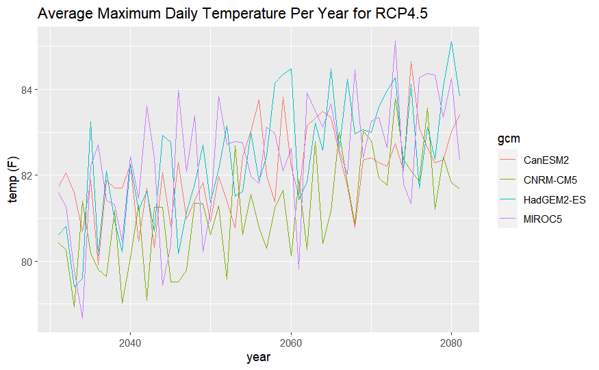

```r
ggplot(data = pt1_rcp45_tbl, aes(x = as.Date(dt), y = as.numeric(temp_f))) +
  geom_line(aes(color=gcm)) +
  labs(title = "Average Maximum Daily Temperature Per Year for RCP4.5", x = "year", y = "temp (F)")
```

### Challenge 2

Modify the above to create a similar plot for RCP 8.5. [[Answer](https://bit.ly/3F4Vity)].

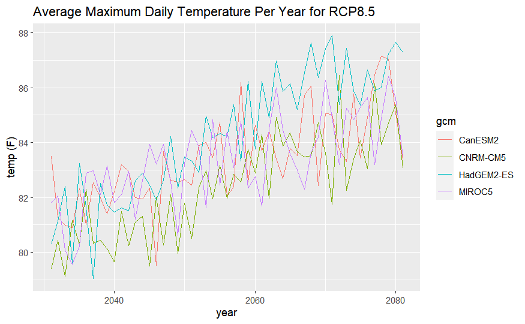

```r
pt1_rcp85_tbl <- pt1_tbl %>%
  filter(scenario == "rcp85", cvar == "tasmax") %>%
  mutate(temp_f = set_units(val, degF))

ggplot(data = pt1_rcp85_tbl, aes(x = as.Date(dt), y = as.numeric(temp_f))) +
  geom_line(aes(color=gcm)) +
  labs(title = "Average Maximum Daily Temperature Per Year for RCP8.5", x = "year", y = "temp (F)")
```

### Challenge 3

For the same point, make a plot of average maximum temperature year for the same 4 GCMs for the period 1950-2005. [[Hint](https://bit.ly/3oWB12V)]. [[Answer](https://bit.ly/3I3ZVp2)].

```r
pt1_hist_cap <- ca_loc_pt(coords = c(-119.168765, 35.487802)) %>%
  ca_gcm(gcms[1:4]) %>%
  ca_scenario("historical") %>%
  ca_period("year") %>%
  ca_years(start = 1950, end = 2005) %>%
  ca_cvar("tasmax")

pt1_hist_cap %>% ca_preflight()
```

```
General issues
 - none found
Issues for querying values
 - none found
Issues for downloading rasters
 - none found
```

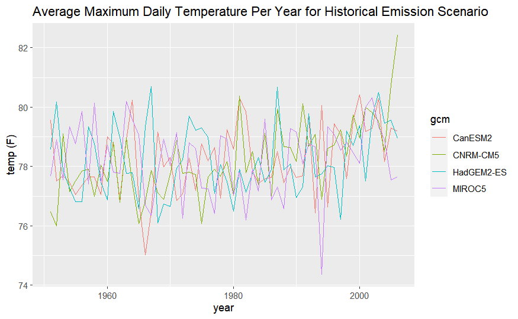

```r
pt1_hist_tbl <- pt1_hist_cap %>%
  ca_getvals_tbl(quiet = TRUE)

pt1_hist_degf_tbl <- pt1_hist_tbl %>%
  mutate(temp_f = set_units(val, degF))

ggplot(data = pt1_hist_degf_tbl, aes(x = as.Date(dt), y = as.numeric(temp_f))) +
  geom_line(aes(color=gcm)) +
  labs(title = "Average Maximum Daily Temperature Per Year for Historical Emission Scenario", x = "year", y = "temp (F)")
```